```python
import numpy as np, pandas as pd, scipy.stats, sympy, matplotlib.pyplot as plt,matplotlib as mpl, math
from numpy import random_intel
plt.rc('font', family='serif')
plt.rc('text', usetex=True)
mpl.rcParams['figure.dpi'] = 150
mpl.rcParams['savefig.dpi'] = 300
```

# Exercise 3

- Generate simulated values from the following distributions
  - Exponential distribution
  - Normal distribution (at least with Box-Mueller)
  - Pareto distribution, with $β = 1$ and experiment with different values of $k$ values: $k = 2.05$, $k = 2.5$, $k = 3$ og $k = 4$.
- Verify the results by comparing histograms with analytical results and erform tests for distribution type.
- For the Pareto distribution with support on $[β, ∞[$ comparemean value and variance, with analytical results, which can be calculated as $E\{X\} = β \frac{k}{k-1}$ (for $k > 1$) and $k−1$ $Var\{X\} = β^2 \frac{k}{(k-1)^2(k-2)}$ (for $k > 2$)
- For the normal distribution generate 100 95% confidence intervals for the mean and variance based on 10 observations. Discuss the results.

First, a series of random numbers are generated as in Exercise 2.

```python
np.random_intel.seed(123)
U = np.random_intel.rand(10000)
U2 =np.roll( np.random_intel.rand(10000),1000)
print(U[:5])
print(U2[:5])
```

```
[0.0523636  0.26767717 0.08718668 0.76895639 0.40724176]
[0.88993355 0.43060588 0.69815744 0.73120447 0.35602689]
```

## Exponential distribution

The time between events in a Poisson process is exponentially distributed. (Arrival time) \begin{equation} F(x)=1−e(−λx)\quad E(X)= \frac{1}{\lambda}\quad F^{−1}(u)=−\frac{1}{\lambda}log(1−u) \end{equation} So (both $1 − U$ and $U$ is uniform distributed) $X = \frac{−log(U)}{\lambda} ∼ exp(λ)$

The exponential distribution is thus generated as:

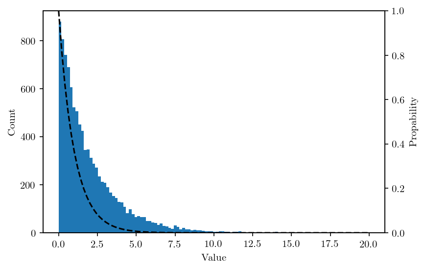

```python
l = 0.5
X_exp = -np.log(U)/l
ex = scipy.stats.expon(0)
x = np.linspace(0,20,100)

fig, ax1= plt.subplots(1)
ax1.hist(X_exp,bins=100)
ax1.set_xlabel("Value")
ax1.set_ylabel("Count")
ax2 = ax1.twinx()
ax2.plot(x,ex.pdf(x),"--k")
ax2.set_ylim([0,1])
ax2.set_ylabel("Propability")
plt.show()
```

The he distribution is visualized in the above figure.

## Pareto

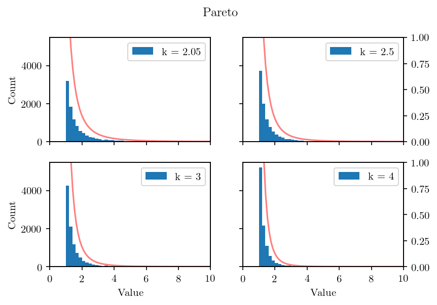

```python
X_pareto = lambda U,beta,k: beta*(U**(-1/k))
beta = 1
k = [2.05,2.5,3,4]
fig, axarr = plt.subplots(2,2,sharey=True,sharex=True)
axarr = axarr.flatten()

x = np.linspace(0.1,11,100)
Pareto = lambda x,k : k*1**k/x**(k+1)

for i,j in enumerate(k):
    #axarr[i].title("k = "+str(i))
    axarr[i].hist(X_pareto(U,beta,j),50,range=[0,10],label="k = {}".format(j))
    axarr[i].set_xlim([0,10])
    axarr[i].legend()
    if i not in [0,1]:
        axarr[i].set_xlabel("Value")
    if i in [0,2]:
        axarr[i].set_ylabel("Count")
    ax2 = axarr[i].twinx()
    ax2.plot(x,Pareto(x,j) ,'-r',alpha = 0.5)
    ax2.set_ylim([0,1])
    if i in [0,2]:
        ax2.get_yaxis().set_visible(False)
fig.suptitle('Pareto')
plt.show()
```

Looking at the above graphs it is very apperent how the values of $k$ influence the distribution. The red line is the theoretical probability distribution function.

## Gaussian

$X$ a result of many $(∞)$ independent sources (Central limit theorem) \begin{equation} X ∼ N(μ,σ2) \end{equation} \begin{equation} Z ∼ N(0, 1) \quad X ∼ N(μ,σ2) \quad X = μ + σZ \quad Z = Φ−1(U) \end{equation}

The Box-Muller method A transformation from polar $(θ = 2πU2, r = \sqrt{−2 log(U1))}$ into cartisan \begin{equation} \begin{bmatrix} Z1 \\ Z2\end{bmatrix}= \sqrt{−2 log(U1))} \begin{bmatrix}cos(2πU2)\\sin(2πU2) \end{bmatrix} \end{equation}

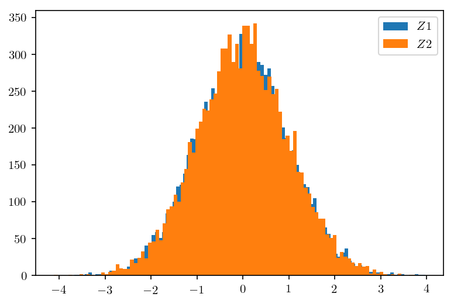

```python
Z =np.multiply(np.sqrt([-2*np.log(U)]),np.array([np.cos(2*math.pi*U2),np.sin(2*math.pi*U2)]))
plt.hist(Z[0],100,label='$Z1$')
plt.hist(Z[1],100,label='$Z2$')
plt.legend()
plt.show()
```

## χ2

The χ2 test will be performed over a series of 100 number generations. First T is calculated:

```python
Tarr = []
nobsArr = [] # For later use
Uarr = []
for i in range(100):
    U = LCG(i,a=1664525,c=1013904223,M=2**32,N=N)
    Uarr.append(U)
    nobs,_ = np.histogram(U,bins=10)
    nobsArr.append(nobs)
    Tarr.append(((nobs-N/n)**2/(N/n)).sum())
T = np.mean(Tarr)
print("T_mean = ",T)
plt.plot(Tarr, label="T-values")
plt.plot([0,100],[T,T],'--',c='gray', label="Mean")
plt.xlabel("Test \#");plt.ylabel("T");plt.legend();plt.show()
```

[output not shown]

## Central limit theorem

\begin{equation} X=\sum_{i=1}^nU_i−\frac{n}{2} \end{equation}

```
array([ 0.79155996,  1.77359225,  0.12259062, ..., -0.06276212,
       -0.50413977, -0.96619476])
```

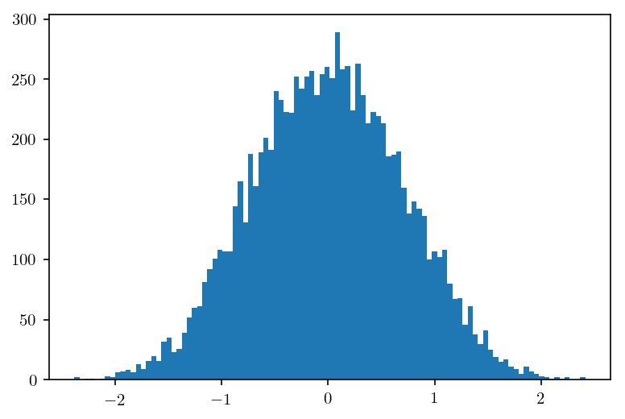

```python
U_i = [np.random.rand(10000) for _ in range(6)]
X = np.sum(np.array(U_i),axis = 0)-6/2
plt.hist(X,100)
X
```

Regarding the above distribution it is again seen that the graph model mimics a normal distribution. It is noteworthy that if the amount of uniform distributions is increased then the variance is also increased. This is seen underneath:

```
array([ 0.90553242,  2.64626181,  3.26650161, ..., -0.84440496,
       -1.75927927, -2.84494647])
```

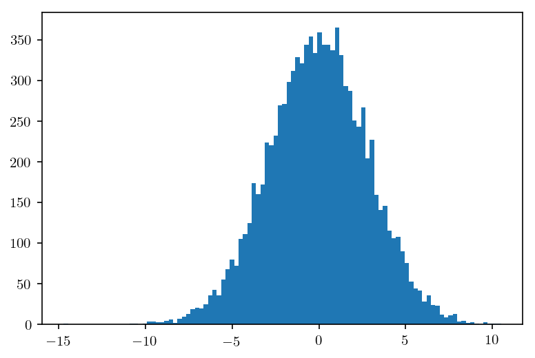

```python
n=100
U_i = [np.random.rand(10000) for _ in range(n)]
X = np.sum(np.array(U_i),axis = 0)-n/2
plt.hist(X,100)
X
```

This indicates that to use the Central limit theorm to generate the distribution a normilzation is nessesary. This can be done using the standard score.

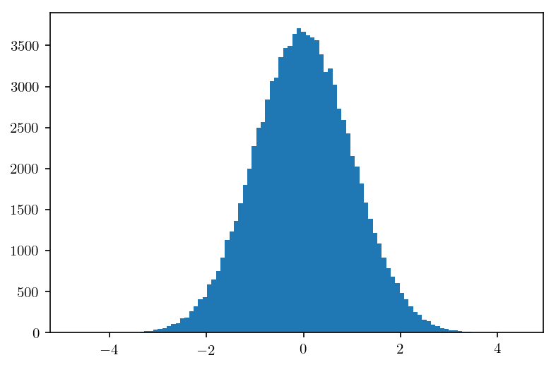

```python
n=100
U_i = [np.random_intel.rand(100000) for _ in range(n)]
X = np.sum(np.array(U_i),axis = 0)-n/2
X = X/X.var()**(1/2)
_,_,_=plt.hist(X,100)
```

# Confidence intervals (Box Mueller)

Generation of 100 95% confidence intervals for 10 observations

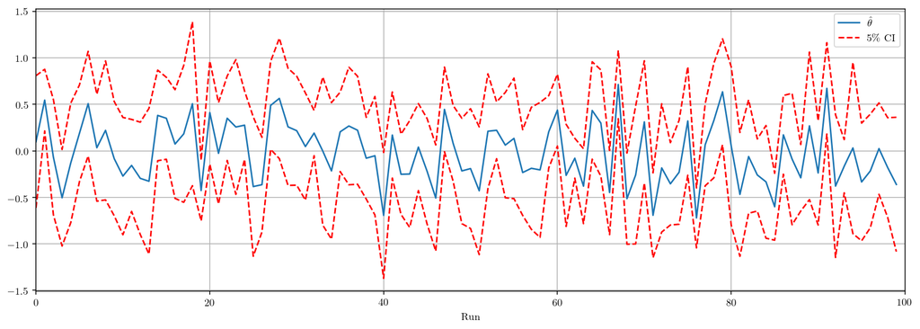

```python
meanArr = []
varArr = []
for _ in range(50):
    U = np.random_intel.rand(10)
    U2 = np.random_intel.rand(10)
    Z =np.multiply(np.sqrt([-2*np.log(U)]),np.array([np.cos(2*math.pi*U2),np.sin(2*math.pi*U2)]))
    meanArr.append(Z[0].mean())
    meanArr.append(Z[1].mean())
    varArr.append(Z[0].var())
    varArr.append(Z[1].var())

meanArr = np.array(meanArr)
varArr = np.array(varArr)
fig,ax = plt.subplots(1,figsize=(15,5))
ax.plot(meanArr,label="$\hat{\\theta}$")
ax.plot(meanArr+(varArr/10)**(1/2)*1.96,'--',c='r')
ax.plot(meanArr-(varArr/10)**(1/2)*1.96,'--',c='r',label="$5\%$ CI")
#plt.plot([-10,120],[meanArr-(varArr/10)**(1/2)*1.96,meanArr-(varArr/10)**(1/2)*1.96],'--',c='r')
ax.set_xlim([0,100])
ax.legend()
plt.xlabel("Run")
ax.grid()
plt.show()
```

The above graph depicts the confidence intervals and mean for each run. It is seen in general that the variance seems similar but en few cases (run 19) is very small. This underlines the importance of running multible simulations to get a indication of the results.

## Pareto

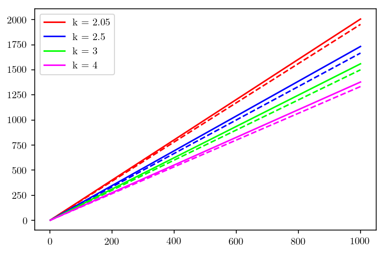

```python
X_pareto = lambda U,beta,k: beta*(U**(-1/k))
beta = np.linspace(1,1e3,1000)
K = [2.05,2.5,3,4]
#par = scipy.stats.pareto()
RAW = []


for k in K:
    for b in beta:
        X = X_pareto(U,b,k)
        mean = np.mean(X)
        var = np.var(X)
        RAW.append([k,b,mean,var])
data = pd.DataFrame(RAW)


data.columns = ['K','Beta','Mean','Var']
color = ['r','b','lime','magenta']
for i,k in enumerate(K):
    plt.plot(data['Beta'][data['K']==k],data['Mean'][data['K']==k],label = "k = {}".format(k),c= color[i])
    plt.plot(beta,beta*(k/(k-1)),'--',c= color[i])
plt.legend()
plt.show()
```

In the above graph it is seen that the estimated mean values (Solid line) are very close to the theoretical (dashed line).

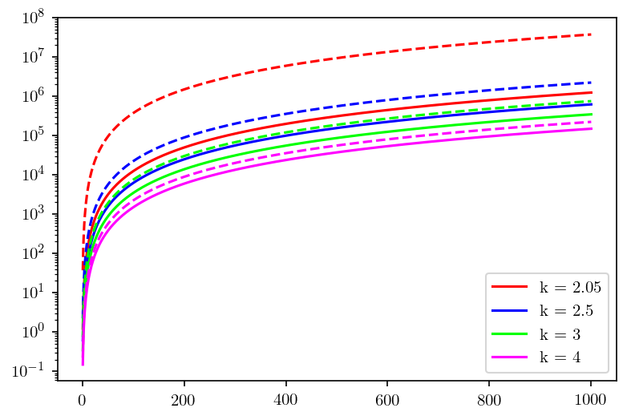

```python
for i,k in enumerate(K):
    plt.plot(data['Beta'][data['K']==k],data['Var'][data['K']==k],label = "k = {}".format(k),c= color[i])
    plt.plot(beta,beta**2*(k/((k-1)**2*(k-2))),'--',c= color[i])
    plt.semilogy()
plt.legend()
#plt.semilogy()
plt.show()
#plt.scatter(data['Beta'],data['Var'],s=0.1)
```